# Fatorial duplo em blocos casualizados

Eric Gorgens

1/17/2021

No caso de um fatorial duplo em blocos casualizados, a ANOVA contará com cinco fontes de variação: uma fonte de variação conhecida atribuída ao bloco, outra fonte de variação conhecida determinada pelo tratamento A, outra fonte de variação conhecida determinada pelo tratamento B, outra fonte de variação conhecida determinada pela interação entre os dois tratamentos e uma quinta fonte de variação desconhecida determinada pelo resíduo. O modelo estatístico do delineamento fatorial duplo inteiramente casualizado é:

$$Y = Xmed + BLOCO + TRAT A + TRAT B + (TRAT A * TRAT B) + Erro$$

De forma semelhante ao experimento fatorial inteiramente casualizado, o caso balanceado será analisado através do pacote ExpDes.pt (função fat2.dbc()). Já o caso desbalanceado será analisado pelo pacote easyanova (função ea2() e design=2).

## O caso balanceado

O exemplo balanceado trata de um experimento no qual se avalia a altura de um experimento fatorial combinando cinco doses de um adubo nitrogenado com três espécies de árvores nativas da Mata Atlântica, organizados em 10 blocos:

- Fator 1: Doses de adubos 0, 25, 50, 75 e 100
- Fator 2: Espécies 2, 5 e 7
- 10 blocos
- Variável de interesse: altura das plantas

Dados de experimento em fatorial DBC

| dose | especie | bloco | altura |
| --- | --- | --- | --- |
| 100 | 2 | 1 | 27.01093 |
| 100 | 2 | 2 | 24.67664 |
| 100 | 2 | 3 | 20.25999 |
| 100 | 2 | 4 | 23.98435 |
| 100 | 2 | 5 | 21.68730 |
| 100 | 2 | 6 | 27.95062 |
| 100 | 2 | 7 | 21.72693 |
| 100 | 2 | 8 | 23.81819 |
| 100 | 2 | 9 | 27.20599 |
| 100 | 2 | 10 | 22.71426 |
| 75 | 2 | 1 | 23.59123 |
| 75 | 2 | 2 | 22.25759 |
| 75 | 2 | 3 | 22.05516 |
| 75 | 2 | 4 | 20.04109 |
| 75 | 2 | 5 | 19.14948 |
| 75 | 2 | 6 | 22.95754 |
| 75 | 2 | 7 | 26.94884 |
| 75 | 2 | 8 | 22.74460 |
| 75 | 2 | 9 | 23.71342 |
| 75 | 2 | 10 | 24.38227 |
| 50 | 2 | 1 | 26.91505 |
| 50 | 2 | 2 | 19.72285 |
| 50 | 2 | 3 | 20.55555 |
| 50 | 2 | 4 | 24.44992 |
| 50 | 2 | 5 | 21.59082 |
| 50 | 2 | 6 | 24.56422 |
| 50 | 2 | 7 | 21.44374 |
| 50 | 2 | 8 | 20.99752 |
| 50 | 2 | 9 | 21.44592 |
| 50 | 2 | 10 | 24.29815 |

[output cut: 120 more lines]

O primeiro passo é importar o arquivo csv contendo os resultados do experimento para dentro do R. Esta tarefa pode ser realizada através do seguinte comando:

```r
fatDBC1 = read.csv("./data/Experimento Fatorial Duplo DBC 1.csv",
                   sep = ",", dec = ".")
```

Para explorar este experimento graficamente, tanto a função boxplot() quanto a função plot() serão usadas. Isto ocorre porque temos um fator quantitativo (doses) e outro fator qualitativos (espécies). Assim, sempre que estivermos analisando o efeito das doses, devemos utilizar gráficos de dispersão. Enquanto que ao analisarmos o efeito dos clones, o boxplot será mais indicado.

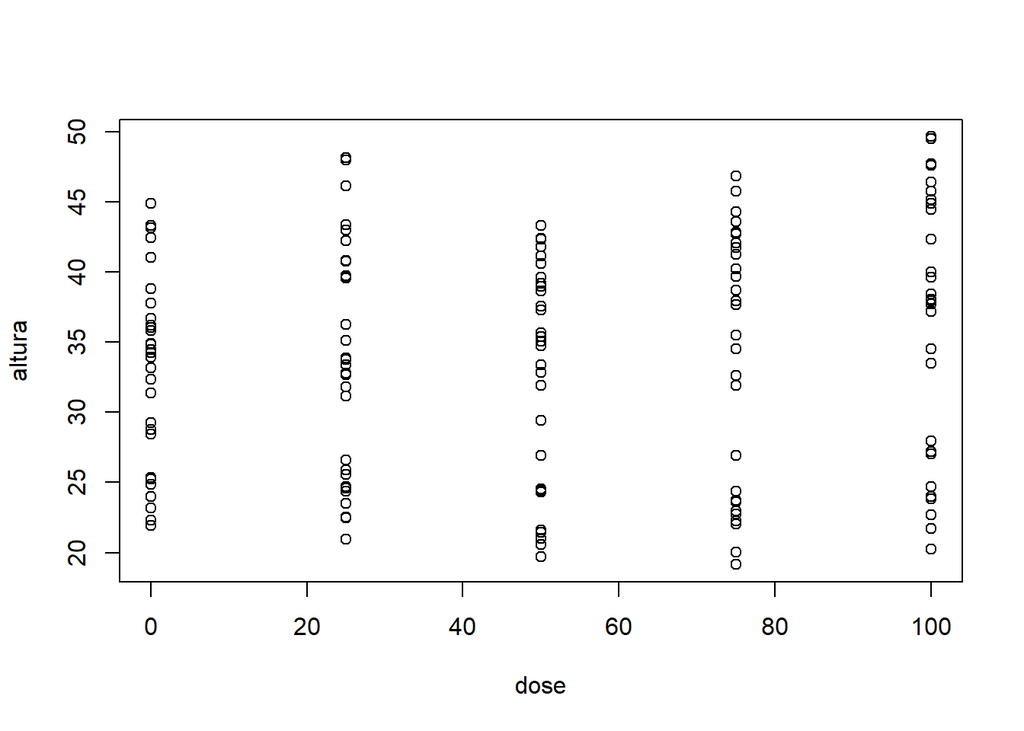

```r
# Considerando apenas fator 1
plot(data = fatDBC1, altura ~ dose)
```

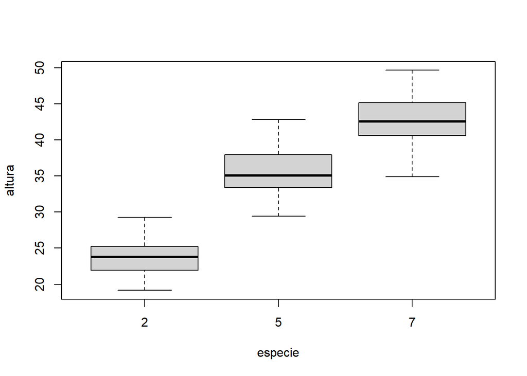

```r
# Considerando apenas fator 2
boxplot(data = fatDBC1, altura ~ especie)
```

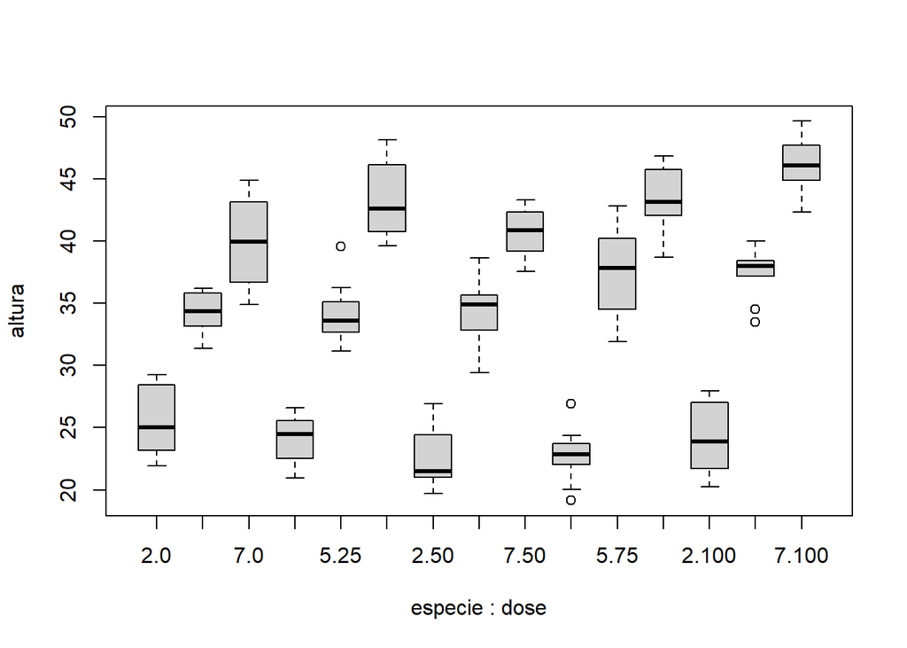

```r
# Interação dos fatores
boxplot(data = fatDBC1, altura ~ especie/dose)
```

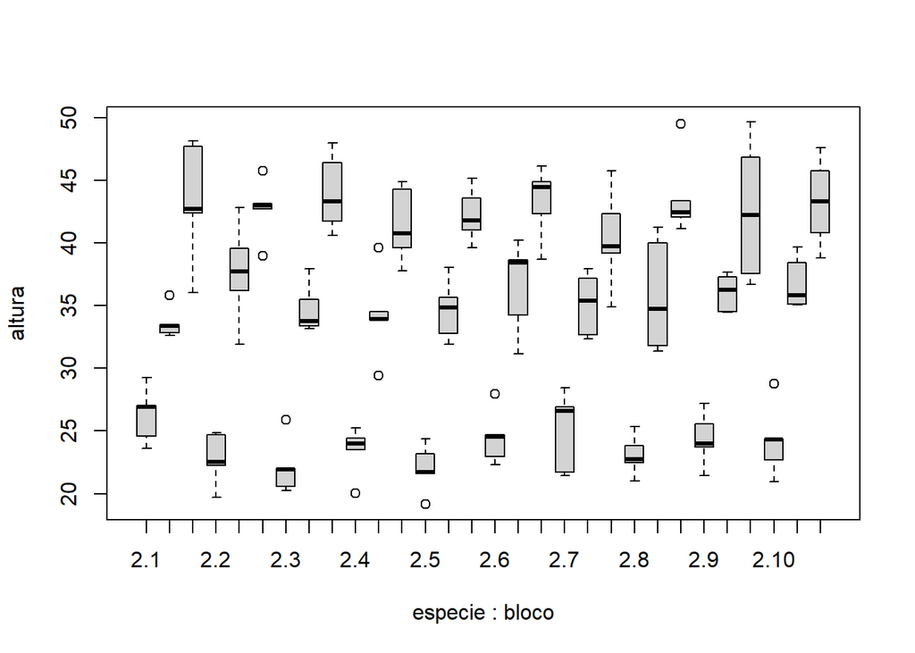

```r
# Efeito dos blocos
boxplot(data = fatDBC1, altura ~ especie/bloco)
```

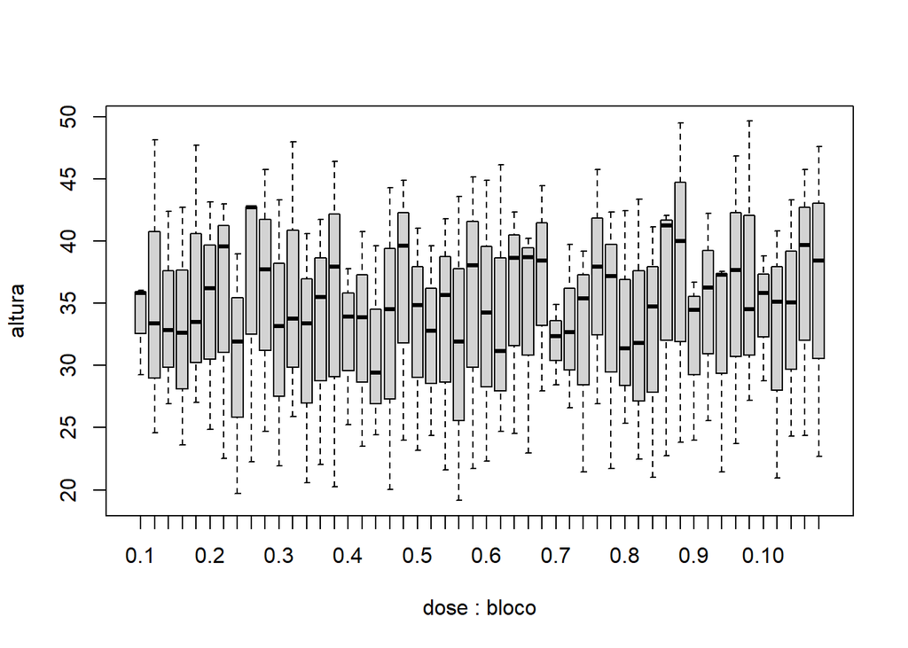

```r
boxplot(data = fatDBC1, altura ~ dose/bloco)
```

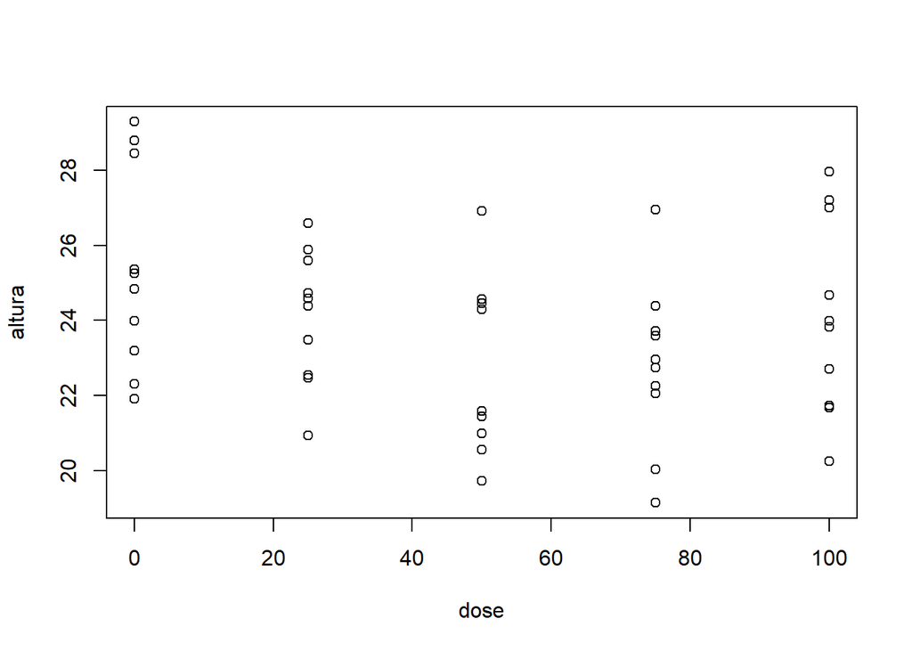

```r
# Isolando os níveis do fator 2
# Fixando especie igual a 2
plot(data = fatDBC1[fatDBC1$especie == 2,], altura ~ dose)
```

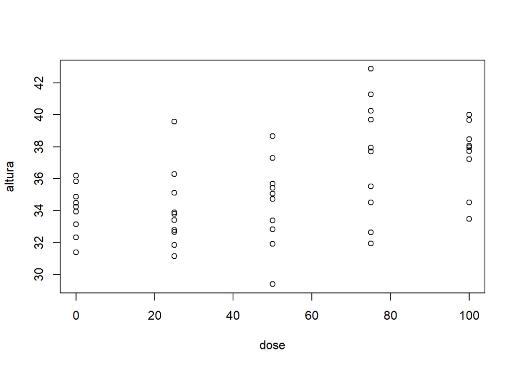

```r
# Fixando especie igual a 5
plot(data = fatDBC1[fatDBC1$especie == 5,], altura ~ dose)
```

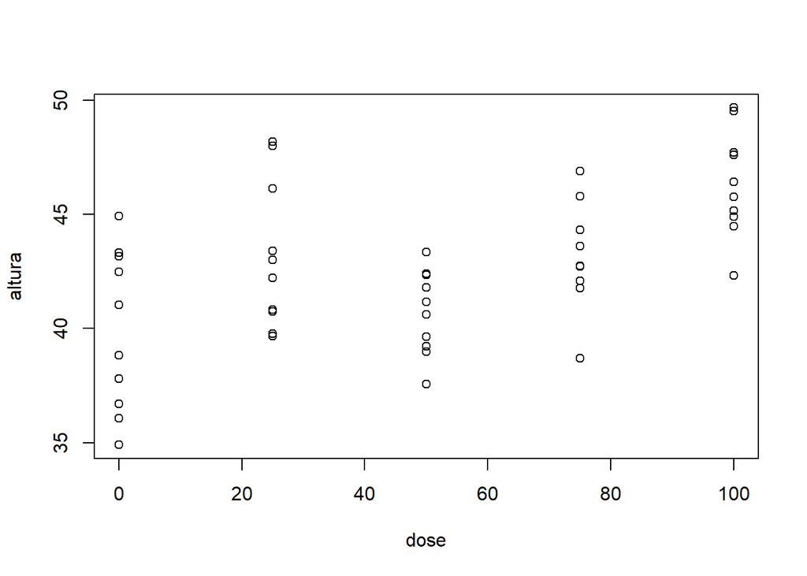

```r
# Fixando especie igual a 7
plot(data = fatDBC1[fatDBC1$especie == 7,], altura ~ dose)
```

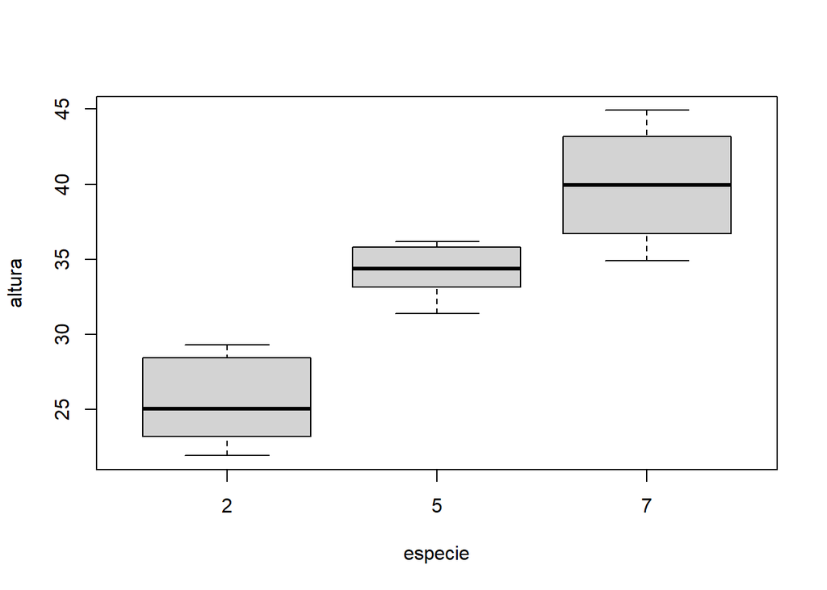

```r
# Isolando os níveis do fator 1
# Fixando dose igual a 0
boxplot(data = fatDBC1[fatDBC1$dose == 0,], altura ~ especie)
```

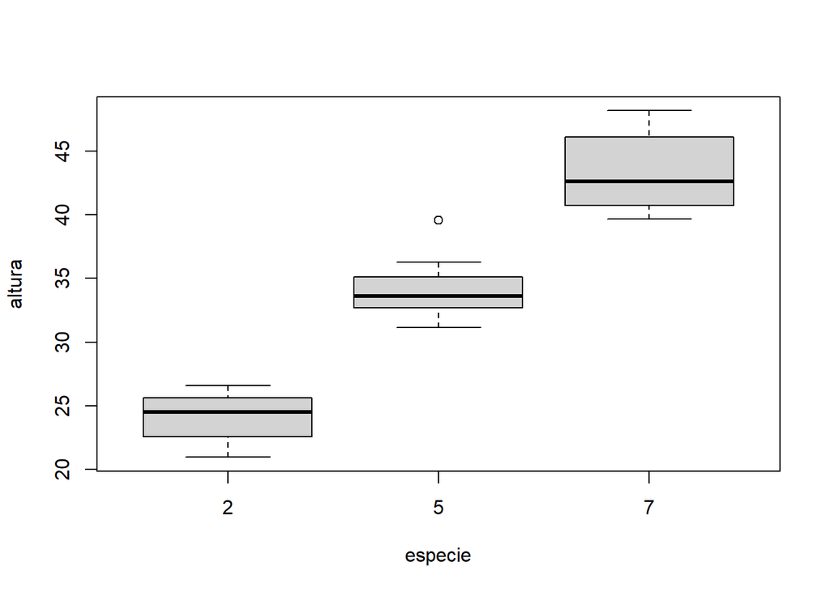

```r
# Fixando dose igual a 25
boxplot(data = fatDBC1[fatDBC1$dose == 25,], altura ~ especie)
```

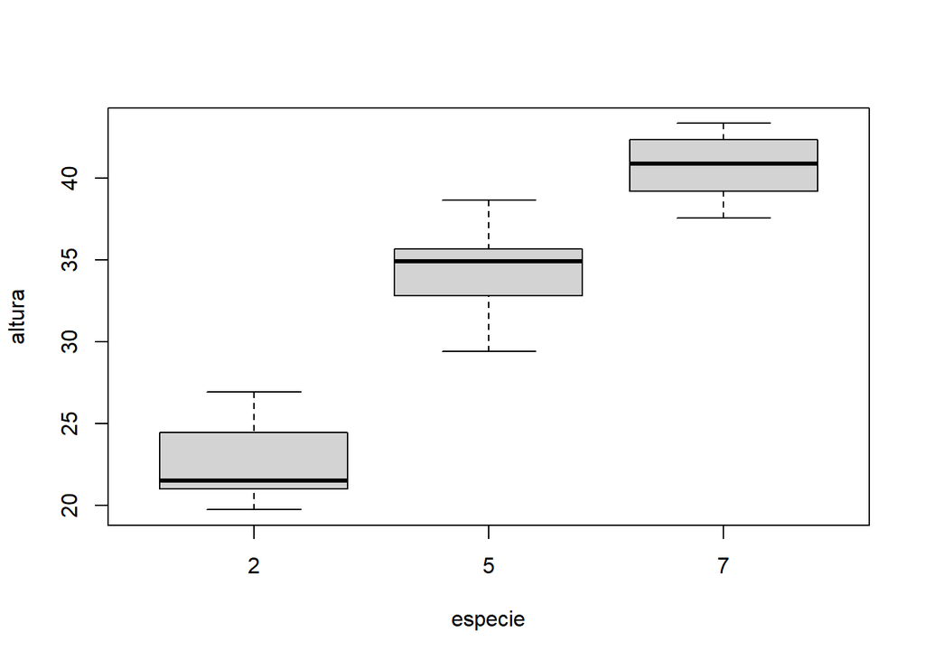

```r
# Fixando dose igual a 50
boxplot(data = fatDBC1[fatDBC1$dose == 50,], altura ~ especie)
```

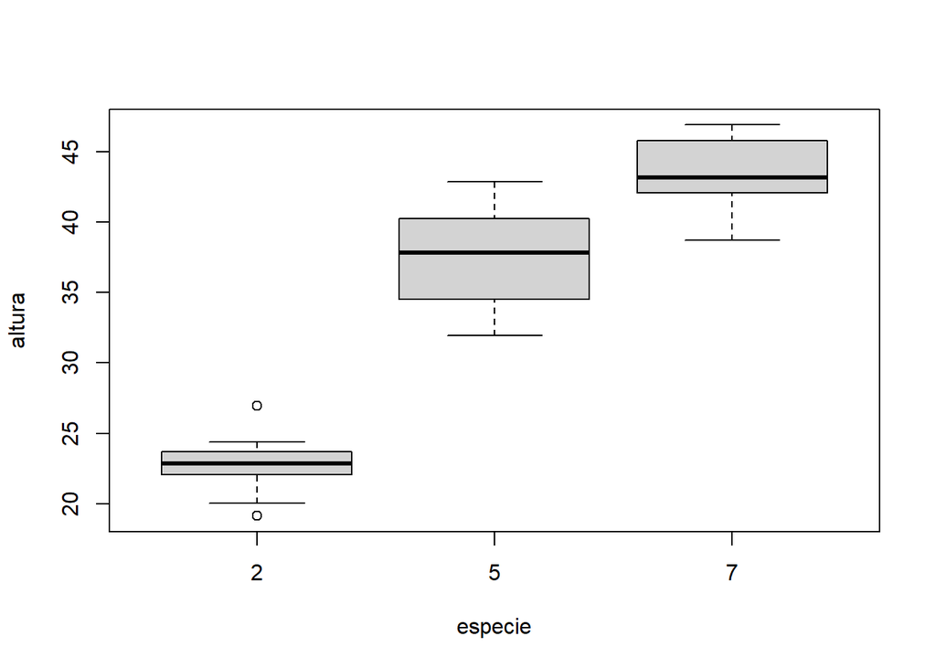

```r
# Fixando dose igual a 75
boxplot(data = fatDBC1[fatDBC1$dose == 75,], altura ~ especie)
```

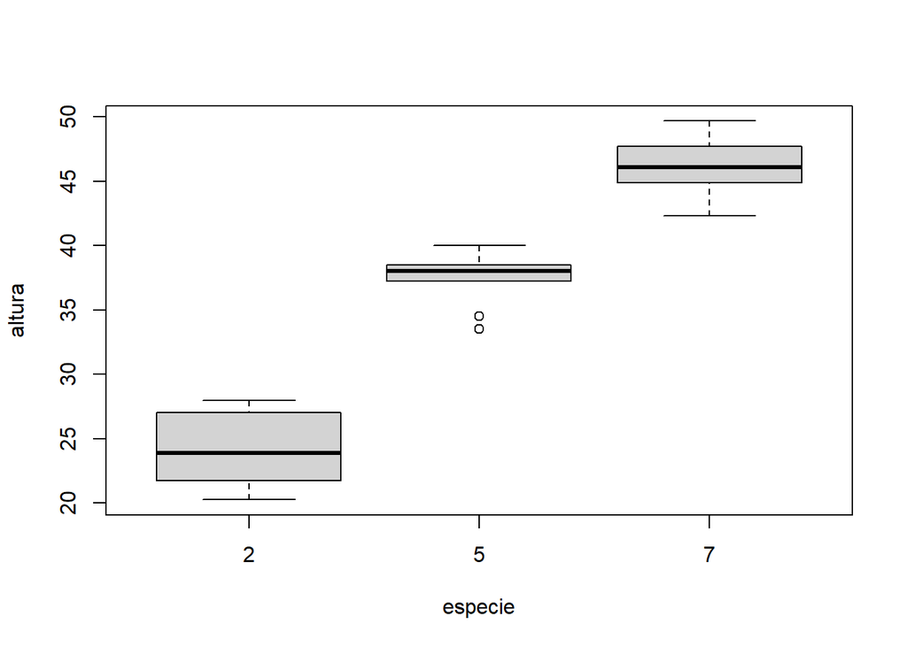

```r
# Fixando dose igual a 100
boxplot(data = fatDBC1[fatDBC1$dose == 100,], altura ~ especie)
```

Com base nos gráficos apresentados, é razoável acreditar que há um efeito significativo da espécie, mas não não fica muito evidente o efeito significativo da dose, da interação e do bloco. Nota-se que as doses possuem comportamentos diferentes, variando de uma tendência quadrática à uma tendência sigmoidal (cúbica).

Note que quanto mais fatores e interações estiverem presentes em nosso experimento, mais complicado vai ficando a análise gráfica e também a análise estatística. E é por este motivo que desencoraja-se o uso de experimentos fatoriais triplos. Embora os pacotes de análise experimental possuam funções para experimentos fatoriais triplos, não apresentaremos exemplos aqui neste livro. Tente discutir um experimento fatorial triplo com efeito dos fatores, interações duplas e interação tripla significativa!

A análise estatística será feita pela função fat2.dbc() do pacote ExpDes.pt. A sintaxe básica da função pode ser vista acessando a página de ajuda da função:

```r
fat2.dbc(fator1, fator2, bloco, resp, quali = c(TRUE, TRUE),
         mcomp = "tukey", fac.names = c("F1", "F2"),
         sigT = 0.05, sigF = 0.05)
```

Lembrando que como temos um fator quantitativo e um fator qualitativo, além dos parâmetros obrigatórios, será necessário ajustar o parâmetro quali:

```r
require(ExpDes.pt)
fat2.dbc(fatDBC1$dose, fatDBC1$especie, fatDBC1$bloco,
         fatDBC1$altura, quali = c(FALSE, TRUE),
         fac.names = c("Dose", "Espécie"))
```

```
## ------------------------------------------------------------------------
## Legenda:
## FATOR 1:  Dose
## FATOR 2:  Espécie
## ------------------------------------------------------------------------
##
##
## Quadro da analise de variancia
## ------------------------------------------------------------------------
##               GL      SQ QM     Fc   Pr>Fc
## Bloco          9    60.5  6   1.03 0.41738
## Dose           4   212.6  4   8.16 0.00001
## Espécie        2  9138.4  3 702.07 0.00000
## Dose*Espécie   8   224.7  2   4.32 0.00013
## Residuo      126   820.0  5
## Total        149 10456.2  1
## ------------------------------------------------------------------------
## CV = 7.5 %
##
## ------------------------------------------------------------------------
## Teste de normalidade dos residuos (Shapiro-Wilk)
## valor-p:  0.6115979
## De acordo com o teste de Shapiro-Wilk a 5% de significancia, os residuos podem ser considerados normais.
## ------------------------------------------------------------------------
##
##
##
## Interacao significativa: desdobrando a interacao
## ------------------------------------------------------------------------
##
## Desdobrando  Dose  dentro de cada nivel de  Espécie
## ------------------------------------------------------------------------
## ------------------------------------------------------------------------
## Quadro da analise de variancia
## ------------------------------------------------------------------------
##                 GL          SQ         QM      Fc  Pr.Fc
## Bloco            9    60.52166    6.72463  1.0333 0.4174
## Espécie          2  9138.36405 4569.18202 702.069      0
## Dose:Espécie 2   4    50.44803   12.61201  1.9379 0.1082
## Dose:Espécie 5   4   128.29922   32.07481  4.9284  0.001
```

[output cut: 240 more lines]

```
## a     7   43.44104
##  b    5   37.43531
##   c   2   22.78412
## ------------------------------------------------------------------------
##
##
##  Espécie  dentro do nivel  100  de  Dose
## ------------------------------------------------------------------------
## Teste de Tukey
## ------------------------------------------------------------------------
## Grupos Tratamentos Medias
## a     7   46.35791
##  b    5   37.55796
##   c   2   24.10352
## ------------------------------------------------------------------------
```

Uma vez que os dados apresentaram normalidade, o modelo estatístico escolhido é adequado e a ANOVA pode ser então considerada. Com exceção do efeito do bloco, todos apresentaram alta significância, incluindo a interação. Desta forma, os efeitos devem ser analisados em conjunto através do desdobramento. O pacote ExpDes.pt já realiza para você.

Fique atento! Não esqueça de definir na função se os fatores são qualitativos ou quantitativos. Como vimos anteriormente, experimentos qualitativos são desdobrados com teste de médias dentro fixando um dos fatores, enquanto que fatores quantitativos são desdobrados através da análise de regressão fixando um dos fatores.

## O caso desbalanceado

O exemplo desbalanceado trata de um experimento no qual se avalia a influência da intensidade do combate contra um determinado inseto na produção de sementes em duas espécies arbóreas, organizadas em 10 blocos:

- Fator 1: Percentuais de combate 100, 50 e 0
- Fator 2: Espécies 2 e 5
- 10 blocos
- Observação perdida: bloco 8 do combate 100 e espécie 2
- Variável de interesse: peso de sementes produzidas em quilos

Dados de outro experimento em fatorial DBC

| combate | especie | bloco | peso |
| --- | --- | --- | --- |
| 100 | 2 | 1 | 21.6 |
| 100 | 2 | 2 | 23.6 |
| 100 | 2 | 3 | 27.6 |
| 100 | 2 | 4 | 22.3 |
| 100 | 2 | 5 | 24.1 |
| 100 | 2 | 6 | 19.9 |
| 100 | 2 | 7 | 22.7 |
| 100 | 2 | 9 | 23.3 |
| 100 | 2 | 10 | 22.6 |
| 50 | 2 | 1 | 22.5 |
| 50 | 2 | 2 | 22.8 |
| 50 | 2 | 3 | 21.8 |
| 50 | 2 | 4 | 25.8 |
| 50 | 2 | 5 | 21.8 |
| 50 | 2 | 6 | 24.0 |
| 50 | 2 | 7 | 19.2 |
| 50 | 2 | 8 | 20.3 |
| 50 | 2 | 9 | 21.0 |
| 50 | 2 | 10 | 21.0 |
| 0 | 2 | 1 | 30.0 |
| 0 | 2 | 2 | 25.8 |
| 0 | 2 | 3 | 27.8 |
| 0 | 2 | 4 | 26.1 |
| 0 | 2 | 5 | 28.9 |
| 0 | 2 | 6 | 34.1 |
| 0 | 2 | 7 | 23.9 |
| 0 | 2 | 8 | 29.5 |
| 0 | 2 | 9 | 21.4 |
| 0 | 2 | 10 | 30.5 |
| 100 | 5 | 1 | 36.0 |
| 100 | 5 | 2 | 40.5 |
| 100 | 5 | 3 | 37.5 |
| 100 | 5 | 4 | 33.0 |
| 100 | 5 | 5 | 38.3 |
| 100 | 5 | 6 | 37.5 |
| 100 | 5 | 7 | 37.5 |
| 100 | 5 | 8 | 39.0 |
| 100 | 5 | 9 | 36.0 |
| 100 | 5 | 10 | 40.5 |
| 50 | 5 | 1 | 32.8 |
| 50 | 5 | 2 | 35.7 |
| 50 | 5 | 3 | 32.4 |
| 50 | 5 | 4 | 37.5 |
| 50 | 5 | 5 | 35.9 |
| 50 | 5 | 6 | 34.2 |
| 50 | 5 | 7 | 40.5 |
| 50 | 5 | 8 | 33.2 |
| 50 | 5 | 9 | 27.5 |
| 50 | 5 | 10 | 32.9 |
| 0 | 5 | 1 | 34.5 |
| 0 | 5 | 2 | 33.0 |
| 0 | 5 | 3 | 37.5 |
| 0 | 5 | 4 | 37.5 |
| 0 | 5 | 5 | 34.5 |
| 0 | 5 | 6 | 28.5 |
| 0 | 5 | 7 | 30.0 |
| 0 | 5 | 8 | 34.5 |
| 0 | 5 | 9 | 34.5 |
| 0 | 5 | 10 | 46.5 |

O primeiro passo é importar o arquivo csv contendo os resultados do experimento para dentro do R. Esta tarefa pode ser realizada através do seguinte comando:

```r
fatDBC2 = read.csv('./data/Experimento Fatorial Duplo DBC 2.csv',
                   sep = ",", dec = ".")
```

Assim como no experimento balanceado, os dados devem ser explorados graficamente. Diversas opções podem ser utilizadas a partir do pacote gráfico básico. Veja alguns exemplos e tente tirar sua próprias conclusões sobre a análise do experimento que será feita logo em seguida:

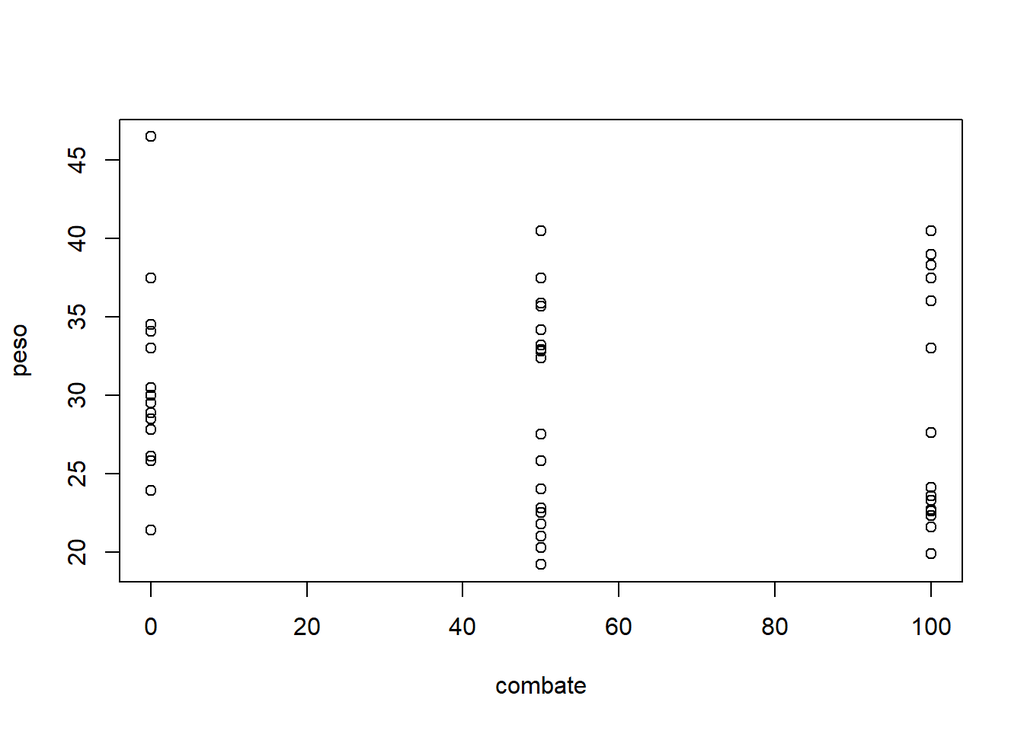

```r
# Considerando apenas fator 1
plot(data = fatDBC2, peso ~ combate)
```

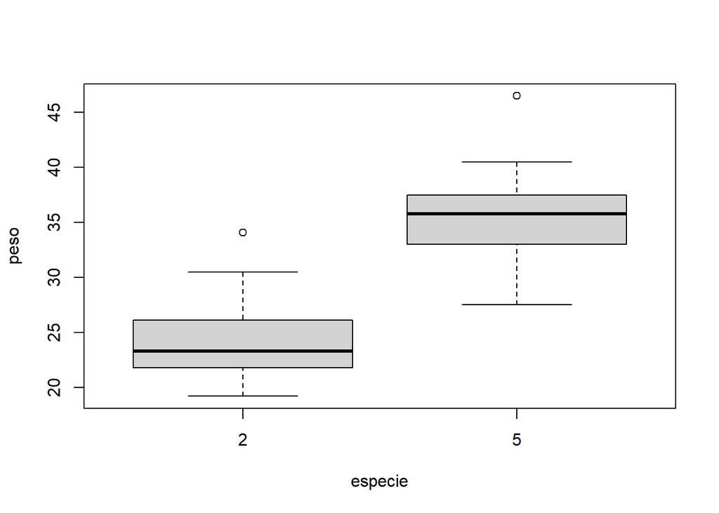

```r
# Considerando apenas fator 2
boxplot(data = fatDBC2, peso ~ especie)
```

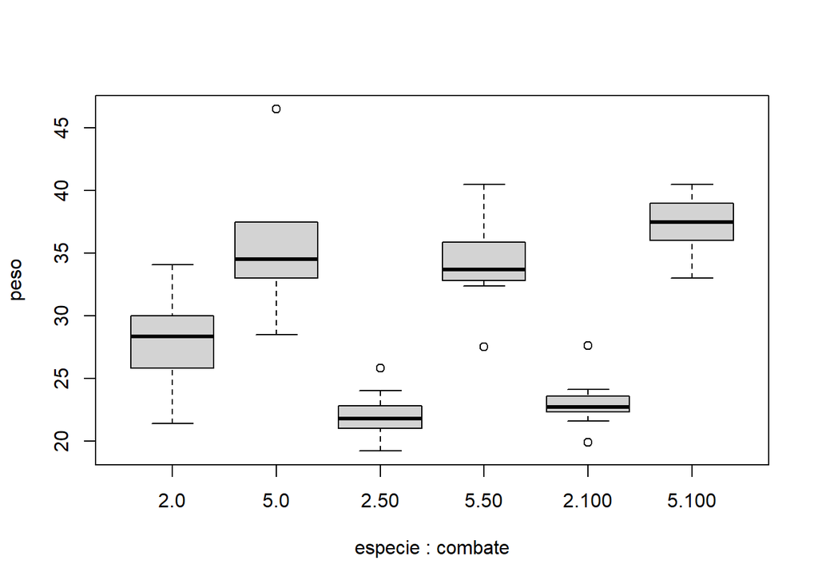

```r
# Interação dos fatores
boxplot(data = fatDBC2, peso ~ especie/combate)
```

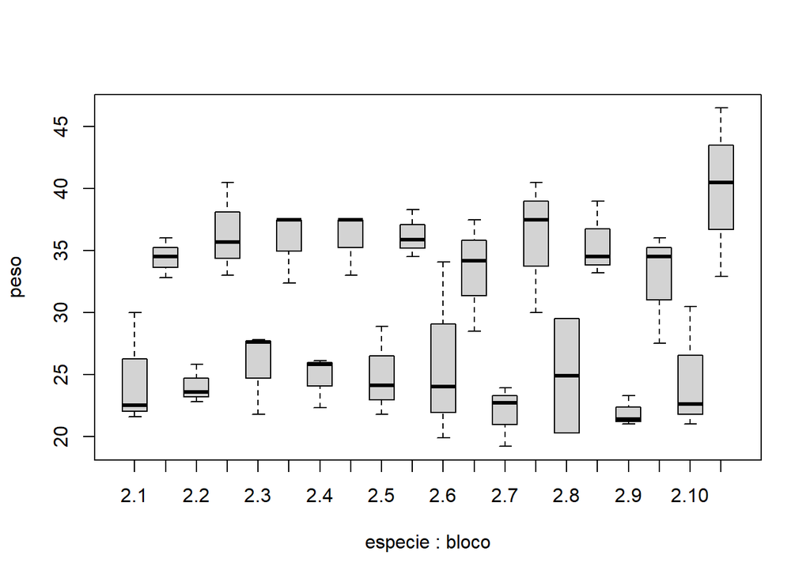

```r
# Efeito dos blocos
boxplot(data = fatDBC2, peso ~ especie/bloco)
```

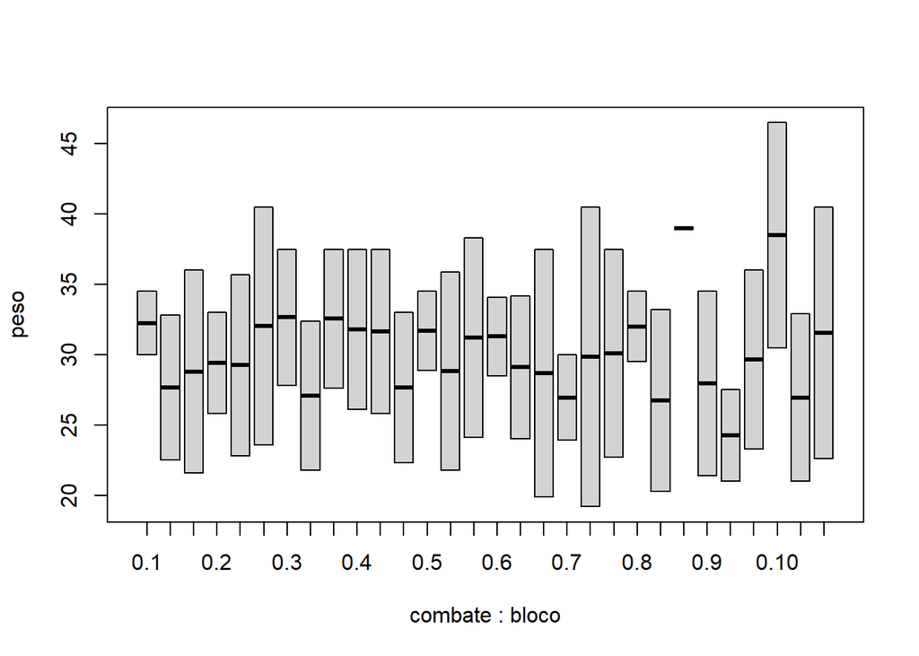

```r
boxplot(data = fatDBC2, peso ~ combate/bloco)
```

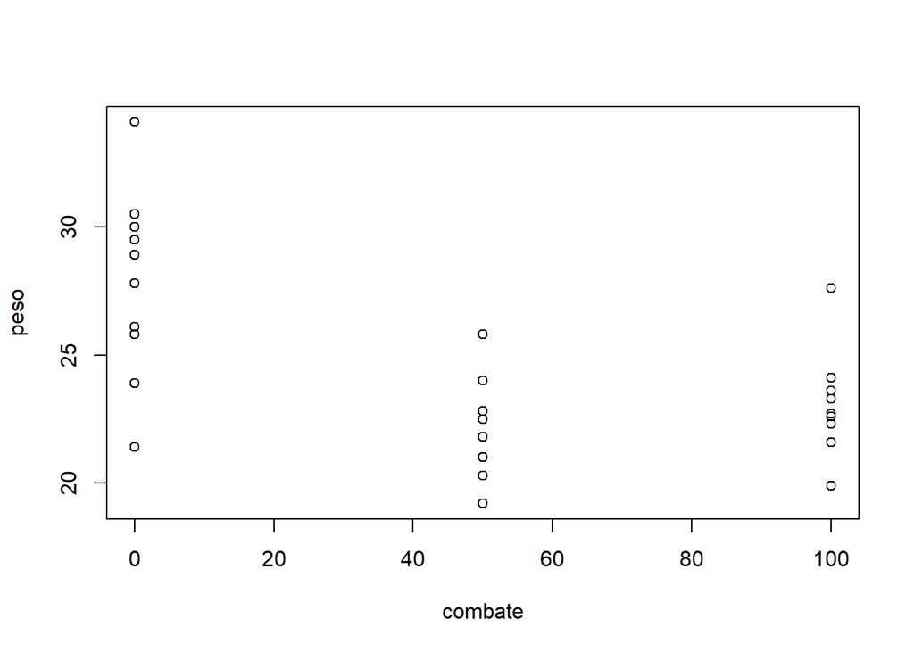

```r
# Isolando os níveis do fator 2
# Fixando especie igual a 2
plot(data = fatDBC2[fatDBC2$especie == 2,], peso ~ combate)
```

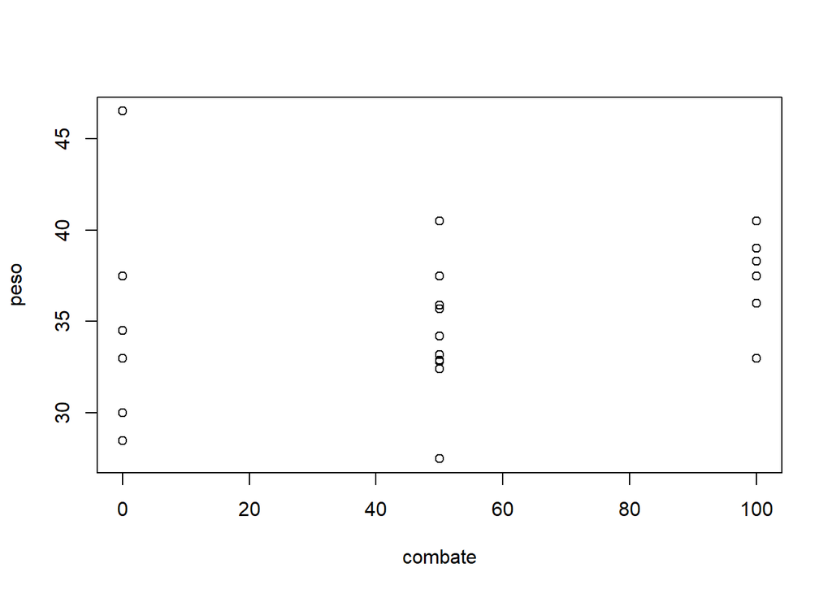

```r
# Fixando especie igual a 5
plot(data = fatDBC2[fatDBC2$especie == 5,], peso ~ combate)
```

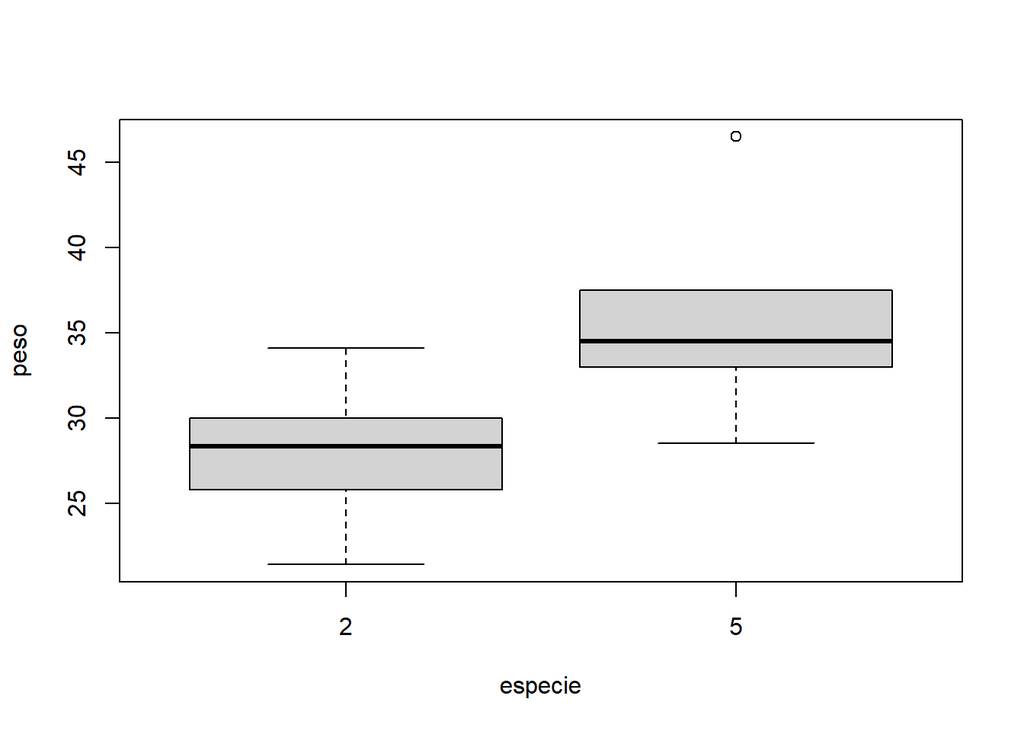

```r
# Isolando os níveis do fator 1
# Fixando combate igual a 0
boxplot(data = fatDBC2[fatDBC2$combate == 0,], peso ~ especie)
```

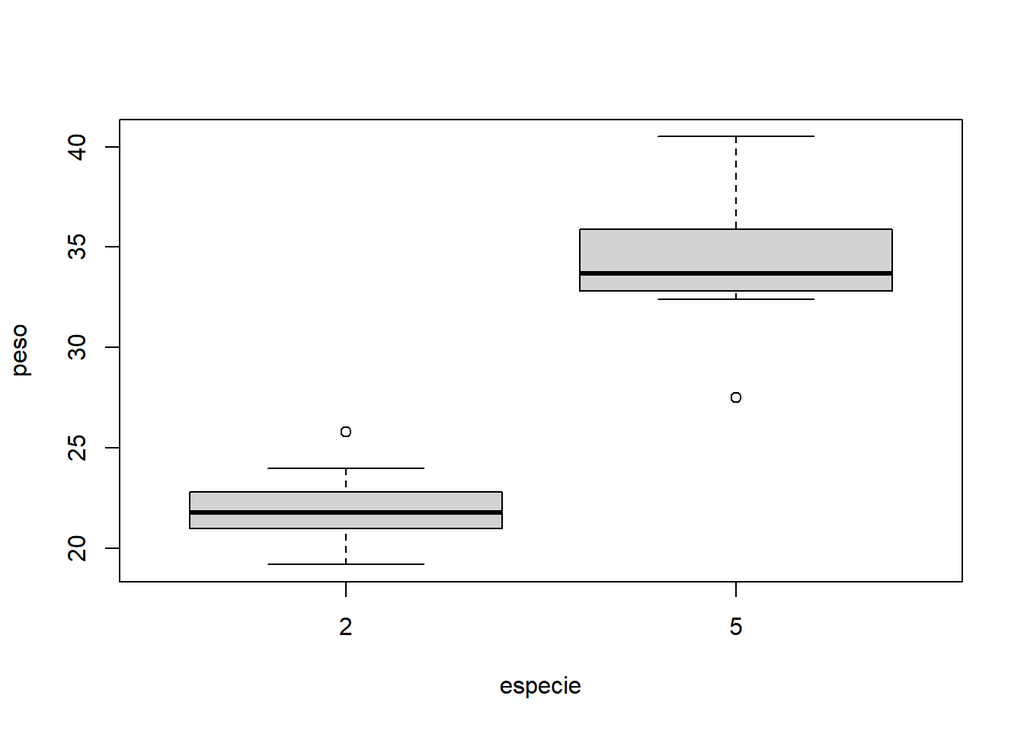

```r
# Fixando combate igual a 50
boxplot(data = fatDBC2[fatDBC2$combate == 50,], peso ~ especie)
```

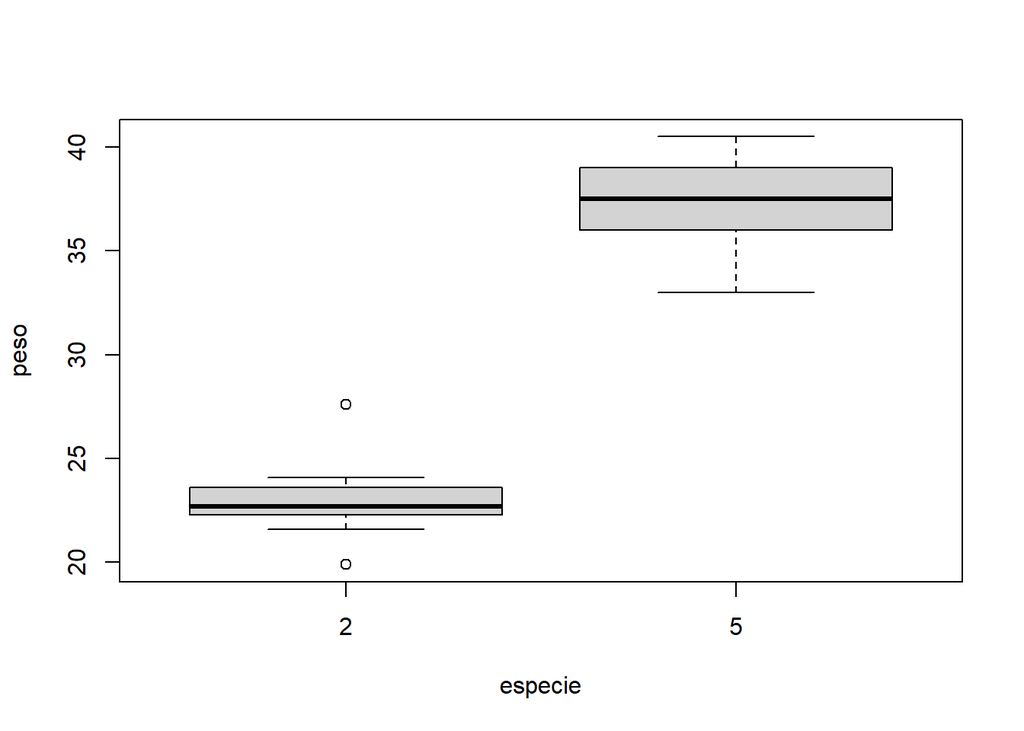

```r
# Fixando combate igual a 100
boxplot(data = fatDBC2[fatDBC2$combate == 100,], peso ~ especie)
```

Como o delineamento fatorial duplo em blocos casualizados pode ter a interação significativa, é fundamental considerar a análise através da ANOVA tipo III. A sintaxe da função é:

```r
ea2(data, design = 1, alpha = 0.05, cov = 4, list = FALSE,
    p.adjust=1,plot=2)
```

Como já mencionado, o pacote easyanova exige que os dados sejam apresentados em forma de dataframe contendo apenas as colunas relevantes para a análise. No caso de um experimento fatorial duplo em blocos casualizados, a ordem esperada das colunas é:

1. Fator A
2. Fator B
3. Bloco
4. Variável resposta

Qualquer variável extra deve ser removida dos dados e a ordem acima deve ser respeitada para o correto uso do pacote. Além de apresentar os dados na estrutura correta, o parâmetro design deve ser ajustado para 2, indicando fatorial duplo em blocos casualizados.

```r
require(easyanova)
r.aov = ea2(fatDBC2, design = 2)
```

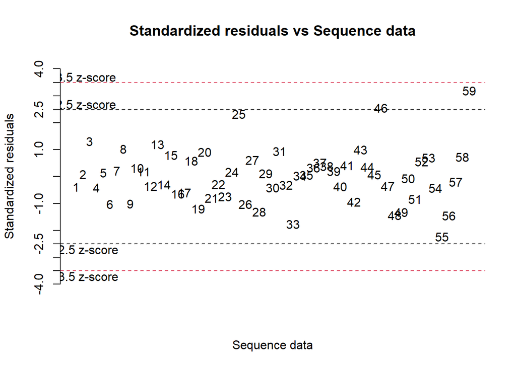

Os resultados são armazenados numa lista de 10 posições, aqui salva numa variável denominada de r.aov. As 10 posições contém:

1. Análise de variância
2. Comparação de médias do fator 1
3. Teste de comparação múltipla do fator 1
4. Comparação de médias do fator 2
5. Teste de comparação múltipla do fator 2
6. Comparação de médias do fator 1 dentro dos níveis do fator 2
7. Teste de comparação múltipla do fator 1 dentro dos níveis do fator 2
8. Comparação de médias do fator 2 dentro dos níveis do fator 1
9. Teste de comparação múltipla do fator 2 dentro dos níveis do fator 1
10. Análise das pressuposições

Nota-se que o teste de Shapiro-Wilk não é significativo, aceitando-se portanto o teste de nulidade: os resíduos são normais.

```r
r.aov[10]
```

```
## $`Residual analysis`
## $`Residual analysis`$`residual analysis`
##                                     values
## p.value Shapiro-Wilk test           0.0847
## p.value Bartlett test (factor_1)    0.0888
## p.value Bartlett test (factor_2)    0.1543
## p.value Bartlett test (treatments)  0.2051
## coefficient of variation (%)       10.8100
## first value most discrepant        59.0000
## second value most discrepant       46.0000
## third value most discrepant        25.0000
##
## $`Residual analysis`$residuals
##          1          2          3          4          5          6          7
## -1.0666667  0.2666667  3.7333333 -1.1666667  0.4166667 -2.9000000  0.6333333
##          8          9         10         11         12         13         14
##  2.9166667 -2.8333333  0.8853333  0.5186667 -1.0146667  3.3853333 -0.8313333
##         15         16         17         18         19         20         21
##  2.2520000 -1.8146667 -1.6680000  1.6686667 -3.3813333  2.6053333 -2.2613333
##         22         23         24         25         26         27         28
## -0.7946667 -2.0946667  0.4886667  6.5720000 -2.8946667  1.7520000 -3.7113333
##         29         30         31         32         33         34         35
##  0.3386667 -1.1746667  2.6586667 -0.8746667 -4.9746667  0.1086667  0.1920000
##         36         37         38         39         40         41         42
##  0.9253333  1.4720000  1.1086667  0.5586667 -1.0546667  1.1786667 -2.6546667
##         43         44         45         46         47         48         49
##  2.8453333  1.0286667  0.2120000  7.2453333 -1.0080000 -4.0713333 -3.7213333
##         50         51         52         53         54         55         56
## -0.1946667 -2.3613333  1.6053333  2.0053333 -1.2113333 -6.3280000 -4.0946667
##         57         58         59
## -0.5480000  2.0886667  9.0386667
##
## $`Residual analysis`$`standardized residuals`
##           1           2           3           4           5           6
## -0.37654793  0.09413698  1.31791775 -0.41184930  0.14708903 -1.02373968
##           7           8           9          10          11          12
##  0.22357533  1.02962324 -1.00020543  0.31253478  0.18309643 -0.35819122
##          13          14          15          16          17          18
##  1.19506899 -0.29347204  0.79498681 -0.64060216 -0.58882682  0.58906216
##          19          20          21          22          23          24
## -1.19365693  0.91971831 -0.79828161 -0.28052821 -0.73944599  0.17250602
##          25          26          27          28          29          30
##  2.32000592 -1.02185694  0.61847997 -1.31015145  0.11955397 -0.41467341
##          31          32          33          34          35          36
##  0.93854571 -0.30876930 -1.75612540  0.03836082  0.06777863  0.32665533
##          37          38          39          40          41          42
##  0.51963614  0.39137450  0.19721698 -0.37231176  0.41608546 -0.93713365
##          43          44          45          46          47          48
##  1.00444160  0.36313341  0.07483890  2.55770180 -0.35583779 -1.43723637
##          49          50          51          52          53          54
## -1.31368158 -0.06872000 -0.83358297  0.56670463  0.70791010 -0.42761724
##          55          56          57          58          59
## -2.23387058 -1.44547336 -0.19345150  0.73732791  3.19077300
```

O quadro geral da ANOVA indica que os dois fatores, bem como a interação são significativos:

```r
r.aov[1]
```

```
## $`Analysis of variance`
##                   df type III SS mean square  F value    p>F
## factor_1           2    113.1605     56.5803    5.349 0.0083
## factor_2           1   1890.1081   1890.1081 178.6876 <0.001
## blocks             9     91.7117     10.1902   0.9634 0.4825
## factor_1:factor_2  2    132.6536     66.3268   6.2704  0.004
## residuals         44    465.4199     10.5777        -      -
```

Parte-se direto, portanto, para a análise dos respectivos desdobramentos presentes nas posições 6 e 8 da lista de resultados (r.aov[6] e r.aov[8]):

```r
# Comparação de médias do fator 1 dentro do fator 2
r.aov[6]
```

```
## $`Adjusted means (factor 1 in levels of factor 2)`
## $`Adjusted means (factor 1 in levels of factor 2)`$`factor_1 in  2`
##   treatment adjusted.mean standard.error tukey snk duncan t scott_knott
## 1       0.2        27.800         1.0285     a   a      a a           a
## 3     100.2        23.072         1.0285     b   b      b b           b
## 2      50.2        22.020         1.0285     b   b      b b           b
##
## $`Adjusted means (factor 1 in levels of factor 2)`$`factor_1 in  5`
##   treatment adjusted.mean standard.error tukey snk duncan  t scott_knott
## 6     100.5         37.58         1.0285     a   a      a  a           a
## 4       0.5         35.10         1.0285     a   a     ab ab           a
## 5      50.5         34.26         1.0285     a   a      b  b           a
```

```r
# Comparação de médias do fator 2 dentro do fator 1
r.aov[8]
```

```
## $`Adjusted means (factor 2 in levels of factor 1)`
## $`Adjusted means (factor 2 in levels of factor 1)`$`factor_2 in  0`
##   treatment adjusted.mean standard.error tukey snk duncan t scott_knott
## 4       0.5          35.1         1.0285     a   a      a a           a
## 1       0.2          27.8         1.0285     b   b      b b           b
##
## $`Adjusted means (factor 2 in levels of factor 1)`$`factor_2 in  50`
##   treatment adjusted.mean standard.error tukey snk duncan t scott_knott
## 5      50.5         34.26         1.0285     a   a      a a           a
## 2      50.2         22.02         1.0285     b   b      b b           b
##
## $`Adjusted means (factor 2 in levels of factor 1)`$`factor_2 in  100`
##   treatment adjusted.mean standard.error tukey snk duncan t scott_knott
## 6     100.5        37.580         1.0285     a   a      a a           a
## 3     100.2        23.072         1.0285     b   b      b b           b
```

Fique atento! O pacote easyanova não diferencia fatores qualitativos e quantitativos, analisando todos os fatores e seus desdobramentos com teste comparativo de média.